# FIFA 21 complete player dataset

## by Mennatalla Ibrahim Mohamed Ahmed Khougha

## Preliminary Wrangling

> The dataset of the popular game FIFA 21.

# The top 5 league in the world of football all claim they have the best football in the world, according to FIFA 21 which league has the best players?

### What is the structure of your dataset?

> After tiding my data and we have a data of 3092 raws and 13 columns.

### What is/are the main feature(s) of interest in your dataset?

> The rating and potential of the players

### What features in the dataset do you think will help support your investigation into your feature(s) of interest?

> club name, value and wage work rate

## Univariate Exploration

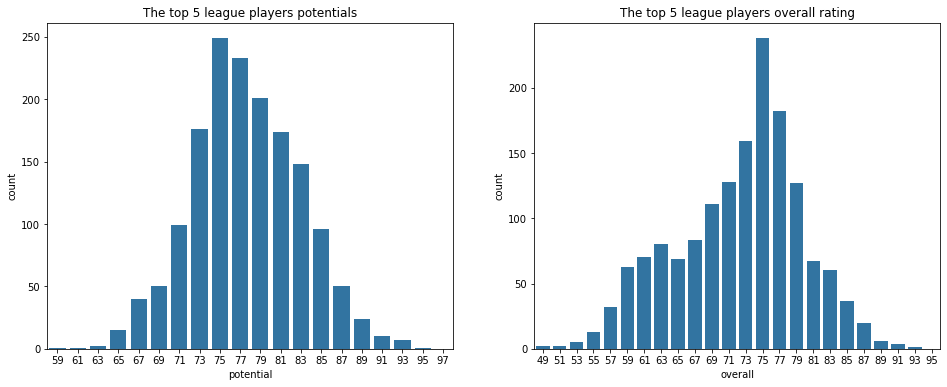

```python
plt.figure(figsize = [16,6])
base_color = sb.color_palette()[0]
plt.subplot(1, 2, 1)
bins = np.arange(59, df["potential"].max()+3, 2)
sb.countplot(data = df, x = "potential", order = bins, color = base_color);
plt.title("The top 5 league players potentials");
plt.subplot(1, 2, 2)
bins = np.arange(49, df["overall"].max()+3, 2)
sb.countplot(data = df, x = "overall", order = bins, color = base_color);
plt.title("The top 5 league players overall rating");
```

### The data show a gradual increase till 75 than a sharp decrease in the number of players with a higher rating and potential

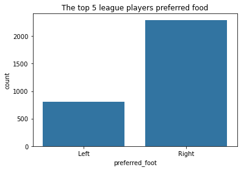

```python
sb.countplot(data = df, x = "preferred_foot", color = base_color);
plt.title("The top 5 league players preferred food");
```

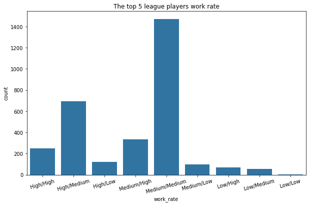

```python
plt.figure(figsize = [10,6])
work = ["High/High", "High/Medium", "High/Low", "Medium/High", "Medium/Medium", "Medium/Low", "Low/High", "Low/Medium", "Low/Low"]
work = pd.api.types.CategoricalDtype(categories = work, ordered = True)
df["work_rate"] = df["work_rate"].astype(work)
sb.countplot(data = df, x = "work_rate", color = base_color);
plt.xticks(rotation = 15);
plt.title("The top 5 league players work rate");
```

### The majority of the player prefer their right foot as for work rate medium/medium is the highest

### Discuss the distribution(s) of your variable(s) of interest. Were there any unusual points? Did you need to perform any transformations?

> The overall rating and potentials are as expected the work rate is interesting because these are the players in the top 5 leagues

### Of the features you investigated, were there any unusual distributions? Did you perform any operations on the data to tidy, adjust, or change the form of the data? If so, why did you do this?

> I had to organize the work rate from highest to lowest!

## Bivariate Exploration

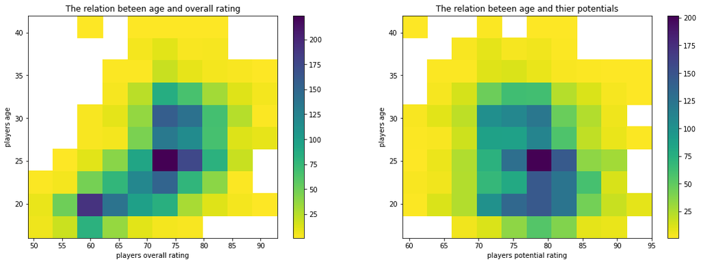

```python
plt.figure(figsize = [18, 6])
plt.subplot(1, 2, 1)
plt.hist2d(data = df, x = 'overall', y = 'age', cmin=0.5, cmap='viridis_r')
plt.colorbar()
plt.ylabel('players age')
plt.xlabel('players overall rating');
plt.title("The relation beteen age and overall rating")
plt.subplot(1, 2, 2)
plt.hist2d(data = df, x = 'potential', y = 'age', cmin=0.5, cmap='viridis_r')
plt.colorbar()
plt.ylabel('players age')
plt.xlabel('players potential rating');
plt.title("The relation beteen age and thier potentials");
```

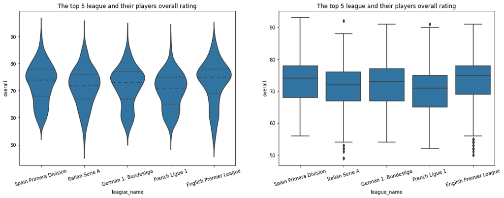

```python
plt.figure(figsize = [18, 6])
plt.subplot(1, 2, 1)
plt.title("The top 5 league and their players overall rating");
sb.violinplot(data = df, x = 'league_name', y = 'overall', color = base_color, inner = "quartile")
plt.xticks(rotation = 15);
plt.subplot(1, 2, 2)
plt.title("The top 5 league and their players overall rating");
sb.boxplot(data = df, x = 'league_name', y = 'overall', color = base_color)
plt.xticks(rotation = 15);
```

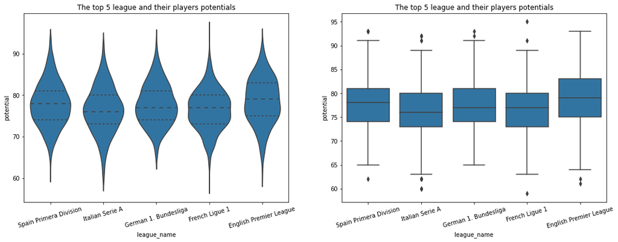

```python
plt.figure(figsize = [18, 6])
plt.subplot(1, 2, 1)
sb.violinplot(data = df, x = 'league_name', y = 'potential', color = base_color, inner = "quartile")
plt.xticks(rotation = 15);
plt.title("The top 5 league and their players potentials")
plt.subplot(1, 2, 2)
sb.boxplot(data = df, x = 'league_name', y = 'potential', color = base_color)
plt.xticks(rotation = 15);
plt.title("The top 5 league and their players potentials");
```

### There is a slight increase in the potentials and overall rating of the players in the English premier league

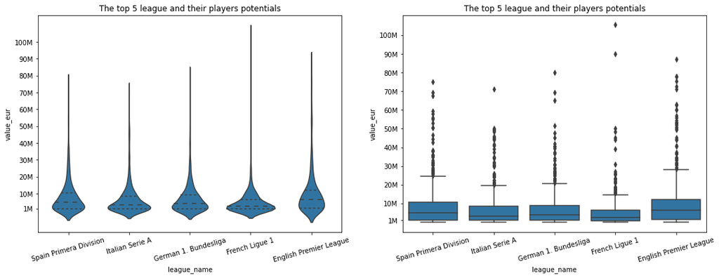

```python
plt.figure(figsize = [18, 6])
plt.subplot(1, 2, 1)
sb.violinplot(data = df, x = 'league_name', y = 'value_eur', color = base_color, inner = "quartile")
ticks = [ 1000000, 10000000, 20000000, 30000000, 40000000, 50000000, 60000000, 70000000, 80000000, 90000000, 100000000]
labels = ["1M", "10M", "20M", "30M", "40M", "50M", "60M", "70M", "80M", "90M", "100M"]
plt.yticks(ticks, labels)
plt.xticks(rotation = 15);
plt.title("The top 5 league and their players potentials")
plt.subplot(1, 2, 2)
sb.boxplot(data = df, x = 'league_name', y = 'value_eur', color = base_color)
ticks = [ 1000000, 10000000, 20000000, 30000000, 40000000, 50000000, 60000000, 70000000, 80000000, 90000000, 100000000]
labels = ["1M", "10M", "20M", "30M", "40M", "50M", "60M", "70M", "80M", "90M", "100M"]
plt.yticks(ticks, labels)
plt.xticks(rotation = 15);
plt.title("The top 5 league and their players potentials");
```

### Despite having the two highest players in value in euros the French Ligue 1 has the largest amount of players with the least value in euros

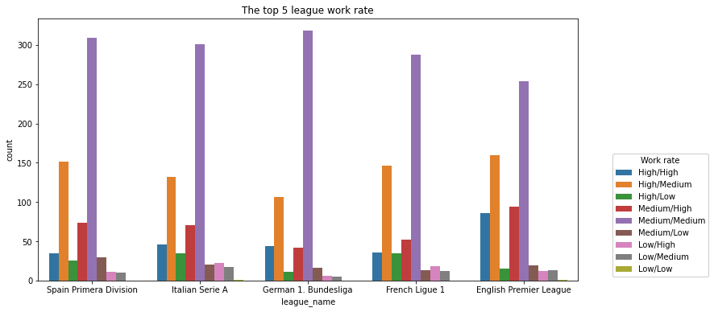

```python
plt.figure(figsize = [12, 6])
sb.countplot(data = df, x = "league_name", hue = "work_rate");
plt.legend(title = "Work rate", framealpha = 1, bbox_to_anchor = (1.25, .5))
plt.title("The top 5 league work rate");
```

### The English premier league have the highest level of work rate (High/High - High/Medium)

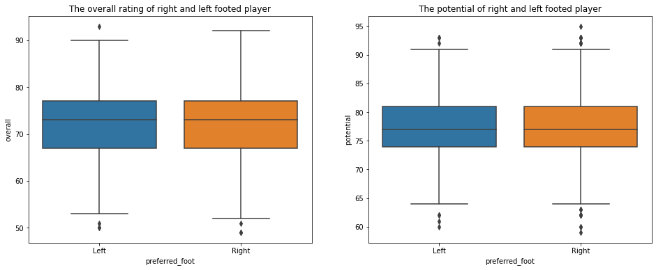

```python
plt.figure(figsize = [16,6])
plt.subplot(1, 2, 1)
sb.boxplot(data = df, x = "preferred_foot", y = "overall");
plt.title("The overall rating of right and left footed player");
plt.subplot(1, 2, 2)
sb.boxplot(data = df, x = "preferred_foot", y = "potential");
plt.title("The potential of right and left footed player");
```

### The player's preferred foot doesn't seem to affect the player's potentials and overall rating.

### Talk about some of the relationships you observed in this part of the investigation. How did the feature(s) of interest vary with other features in the dataset?

> Further investigating the work rate and the leagues showed the English premier league to have the highest work rate!

### Did you observe any interesting relationships between the other features (not the main feature(s) of interest)?

> There is a few older players with high overall and potentials!

## Multivariate Exploration

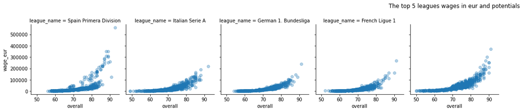

```python
g = sb.FacetGrid(data = df, col = "league_name", col_wrap = 5, height = 3)
g.map(sb.regplot, "overall", "wage_eur",  scatter_kws = {"alpha":1/3}, fit_reg = False, x_jitter = 0.04, y_jitter = 0.04);
plt.title("The top 5 leagues wages in eur and potentials", y = 1.2);
```

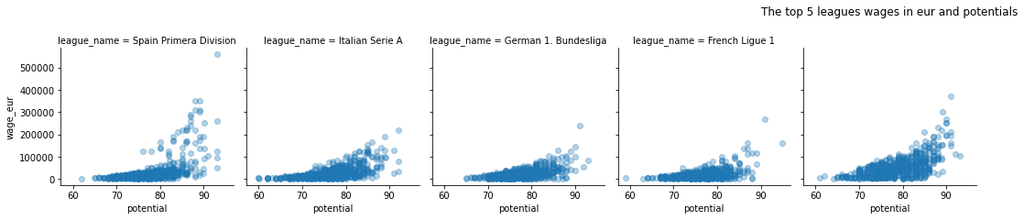

```python
g = sb.FacetGrid(data = df, col = "league_name", col_wrap = 5, height = 3)
g.map(sb.regplot, "potential", "wage_eur", scatter_kws = {"alpha":1/3}, fit_reg = False, x_jitter = 0.04, y_jitter = 0.04);
plt.title("The top 5 leagues wages in eur and potentials", y = 1.2);
```

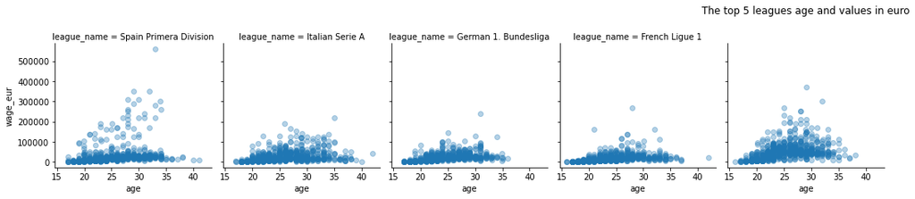

```python
g = sb.FacetGrid(data = df, col = "league_name", col_wrap = 5, height = 3)
g.map(sb.regplot, "age", "wage_eur", fit_reg = False, x_jitter = 0.04, scatter_kws = {"alpha":1/3});
plt.title("The top 5 leagues age and values in euro", y = 1.2);
```

### Talk about some of the relationships you observed in this part of the investigation. Were there features that strengthened each other in terms of looking at your feature(s) of interest?

> I took a look at the top 5 leagues' relation between wages and age, potentials, and overall rating!

### Were there any interesting or surprising interactions between features?

> The clubs of the Spain Primera Division and the English premier league seem to be paying higher wages!